# final_blog

Felicia Cruz

11/26/2021

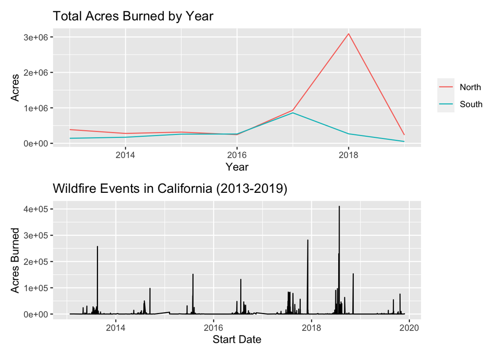

## Are California wildfires more intense in the North or in the South?

**Motivate the question / Introduction** Growing up in the Antelope Valley, located in the Mojave Desert at the northern edge of LA County, I experienced wildfires at a very young age. As I grew up, orange haze outside, flying ash, and evacuation announcements on the news were not out of the ordinary during the later summer months. I will never forget taking a day trip to the beach with my family one summer only to come home to barricades outside our neighborhood because a wildfire had jumped the nearby ridge deeming it unsafe to enter. While our house, and my dog inside, was thankfully intact, we were reminded of the event for months by the charred hill next to our house.

The statistics describing the frequency, intensity, and destructiveness of California wildfires are alarming to say the least, and are all likely to be further exacerbated by the climate crisis in the years to come. As temperature and droughts increase with elevated greenhouse gas emissions, it is probable that we can expect more wildfires in the future, especially with the fire seasons getting longer.

Each year, I hear and read about wildfires all over California. Just this year, I remember talking with some friends about hazy air quality in Santa Barbara. We were wondering if it was due to smoke from fires in the north or the south because there were many wildfires burning at the time.

I am interested in how California wildfires have changed over time, and if this change is different in the north than in the south. Are California wildfires getting more intense in the northern part of the state or in the south? Is there a difference in trends between start date and acres burned for fires in the north versus fires in the South?

From my preliminary research, there does not seem to be existing evidence on this question. While many articles discuss factors that contribute to the growing wildfires in California, there is not much to be said about how geographic location is potentially correlated with changes in wildfires over time.

**Analysis Plan** To assess the effects of wildfire start date and location on the number of acres burned, I will be using the following interaction model:

$$acres\_burned_i=\beta_{0}+\beta_{1} \cdot started_i + \beta_{2} \cdot north\_south_i + \beta_{3} \cdot started_i \cdot north\_south_i + \varepsilon_i$$
The variable `north_south` takes on a value of “North” for all wildfires occurring above 36 degrees latitude, and everything below this is assigned “South”. I have chosen this interaction model in order to see if wildfire trends differ in the north and south.

After running this regression, I will determine if the slope coefficients are statistically significant by looking at the associated p-values.

Table 1: Multiple Linear Regression Output

|  | Estimate | Std. Error | t value | Pr(>\|t\|) |
| --- | --- | --- | --- | --- |
| (Intercept) | -21405.07 | 22705.70 | -0.94 | 0.35 |
| started | 1.57 | 1.31 | 1.19 | 0.23 |
| north_southSouth | 24344.65 | 34590.61 | 0.70 | 0.48 |
| started:north_southSouth | -1.56 | 2.01 | -0.78 | 0.44 |

While this model does show a difference in slopes, because the p-values are so high, these results are not statistically significant. We do not have sound evidence that there is a difference in wildfire intensity over time between the North and South. This brief analysis does not help to answer the original question. More data would be needed to perform a more robust and comprehensive analysis to accurately answer the question “Are California wildfires getting more intense in the northern part of the state or in the south?”

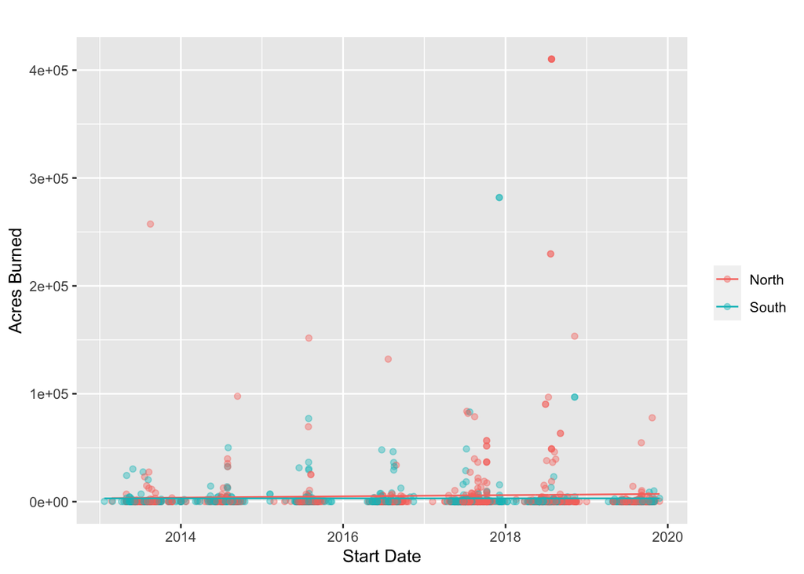

Figure 1: Acres Burned vs. Start Date

**What Next?** - more years of fire data - 7 years is not enough for a robust analysis of the question posed - 2020 fire season is not included - time series analysis/predictions !

In order to accurately answer this question, much more data is needed. This dataset only includes wildfire events during a seven year span. To get a more thorough picture of the trends in acres burned for northern and southern wildfires in California over time, a much larger temporal range is needed beyond the 7 years provided in this dataset. Additionally, this dataset does not include 2020 data which means observations from the largest fire season on record are not taken into account in this preliminary analysis. With more data points spanning a 20-30 year period, I suspect much more interesting and informative results.

Beyond doing a regression analysis to explore differences in geographic trends in wildfire intensity over time, doing time series analyses to produce predictions of wildfire intensity would also be useful. This type of analysis would be of interest to government organizations, first responders in California, and the general public living in fire-prone areas of California.

Lastly, looking at seasonal trends over time can help identify if and how the wildfire season itself is changing. This type of analysis could help answer questions such as: Is the wildfire season in California getting longer? Are more intense wildfires happening at a certain point in the season?

**References** https://www.fire.ca.gov/incidents/2018/ https://www.fire.ca.gov/incidents/2020/ https://www.latimes.com/california/story/2020-10-01/northern-california-fire-season-less-rain-than-southern-california